# Lending_Club_Cluster_Analysis

Group 15

2023-02-25

# Set up

Import Library

```r
#install.packages('factoextra')
#install.packages('psych')
#install.packages('psychTools')
#install.packages('readxl')
library(factoextra)
library(cluster)
library(dplyr)
library(psych)
```

```r
library(psychTools)
library(readxl)
library(ggplot2)
library(tidyverse)
library(GPArotation)
```

# Load data

```r
loan1 <- read_excel("loan_data_ADA_assignment.xlsx")
#Drop Categorical data (that is not ordinal)
rm <- c('member_id','emp_title','issue_d','title','zip_code','addr_state', 'earliest_cr_line','mths_since_last_delinq','mths_since_last_record', 'last_pymnt_d','next_pymnt_d','last_credit_pull_d','policy_code', 'mths_since_last_major_derog','desc', 'purpose', 'pymnt_plan', 'loan_status', 'home_ownership', 'loan_is_bad', 'term')

loan2 <- loan1 %>% select(-rm)
str(loan2)
```

```
## tibble [50,000 × 32] (S3: tbl_df/tbl/data.frame)
##  $ id                        : num [1:50000] 3296446 3286412 3286406 3296434 3286395 ...
##  $ loan_amnt                 : num [1:50000] 11200 10000 8000 16000 4000 15000 8000 19800 4000 14400 ...
##  $ funded_amnt               : num [1:50000] 11200 10000 8000 16000 4000 15000 8000 19800 4000 14400 ...
##  $ funded_amnt_inv           : num [1:50000] 11200 10000 8000 15950 4000 ...
##  $ int_rate                  : num [1:50000] 6.62 11.14 16.29 7.9 7.9 ...
##  $ installment               : num [1:50000] 344 328 282 501 125 ...
##  $ grade                     : chr [1:50000] "A" "B" "C" "A" ...
##  $ sub_grade                 : chr [1:50000] "A2" "B2" "C4" "A4" ...
##  $ emp_length                : num [1:50000] 10 2 7 10 10 10 10 10 NA 3 ...
##  $ annual_inc                : num [1:50000] 108000 65000 35000 110000 155000 ...
##  $ verification_status       : chr [1:50000] "Not Verified" "Not Verified" "Not Verified" "Verified" ...
##  $ dti                       : num [1:50000] 12.52 9.58 27.84 28.87 17.87 ...
##  $ delinq_2yrs               : num [1:50000] 0 0 0 0 0 0 1 0 0 0 ...
##  $ inq_last_6mths            : num [1:50000] 0 0 2 0 0 2 0 1 0 1 ...
```

[output cut: 18 more lines]

```r
summary(loan2)
```

```
##        id            loan_amnt      funded_amnt    funded_amnt_inv
##  Min.   :  58524   Min.   : 1000   Min.   : 1000   Min.   :  950
##  1st Qu.:1443048   1st Qu.: 8000   1st Qu.: 8000   1st Qu.: 7950
##  Median :1587758   Median :12000   Median :12000   Median :12000
##  Mean   :1918444   Mean   :13901   Mean   :13896   Mean   :13878
##  3rd Qu.:2311939   3rd Qu.:19200   3rd Qu.:19200   3rd Qu.:19175
##  Max.   :3304574   Max.   :35000   Max.   :35000   Max.   :35000
##
##     int_rate      installment         grade            sub_grade
##  Min.   : 6.00   Min.   :  25.81   Length:50000       Length:50000
##  1st Qu.:11.14   1st Qu.: 255.66   Class :character   Class :character
##  Median :14.09   Median : 399.26   Mode  :character   Mode  :character
##  Mean   :14.00   Mean   : 436.95
##  3rd Qu.:17.27   3rd Qu.: 567.04
##  Max.   :24.89   Max.   :1388.45
##
##    emp_length       annual_inc      verification_status      dti
##  Min.   : 1.000   Min.   :   5000   Length:50000        Min.   : 0.00
##  1st Qu.: 3.000   1st Qu.:  45000   Class :character    1st Qu.:11.51
##  Median : 6.000   Median :  60000   Mode  :character    Median :17.16
##  Mean   : 5.993   Mean   :  71317                       Mean   :17.37
##  3rd Qu.:10.000   3rd Qu.:  85000                       3rd Qu.:23.05
##  Max.   :10.000   Max.   :7141778                       Max.   :34.99
##  NA's   :1802
##   delinq_2yrs      inq_last_6mths      open_acc        pub_rec
##  Min.   : 0.0000   Min.   :0.0000   Min.   : 0.00   Min.   :0.00000
##  1st Qu.: 0.0000   1st Qu.:0.0000   1st Qu.: 8.00   1st Qu.:0.00000
##  Median : 0.0000   Median :1.0000   Median :10.00   Median :0.00000
##  Mean   : 0.2244   Mean   :0.8389   Mean   :11.01   Mean   :0.05648
##  3rd Qu.: 0.0000   3rd Qu.:1.0000   3rd Qu.:14.00   3rd Qu.:0.00000
##  Max.   :18.0000   Max.   :8.0000   Max.   :53.00   Max.   :8.00000
##
##    revol_bal         revol_util       total_acc      total_pymnt
##  Min.   :      0   Min.   :0.0000   Min.   : 2.00   Min.   :    0
##  1st Qu.:   7102   1st Qu.:0.4310   1st Qu.:16.00   1st Qu.: 7614
##  Median :  12368   Median :0.6150   Median :23.00   Median :12858
##  Mean   :  16011   Mean   :0.5885   Mean   :24.31   Mean   :14828
##  3rd Qu.:  20515   3rd Qu.:0.7750   3rd Qu.:31.00   3rd Qu.:20051
##  Max.   :1743266   Max.   :1.1390   Max.   :99.00   Max.   :57778
##                    NA's   :31
```

[output cut: 17 more lines]

```
##  Min.   :0.00000            Min.   :0.00000   Min.   :    0   Min.   :      0
##  1st Qu.:0.00000            1st Qu.:0.00000   1st Qu.:    0   1st Qu.:  26298
##  Median :0.00000            Median :0.00000   Median :    0   Median :  72117
##  Mean   :0.00114            Mean   :0.00082   Mean   :   52   Mean   : 133594
##  3rd Qu.:0.00000            3rd Qu.:0.00000   3rd Qu.:    0   3rd Qu.: 202362
##  Max.   :2.00000            Max.   :4.00000   Max.   :55009   Max.   :8000078
##                                               NA's   :14618   NA's   :14618
##  total_credit_rv
##  Min.   :      0
##  1st Qu.:  14000
##  Median :  22800
##  Mean   :  29300
##  3rd Qu.:  36600
##  Max.   :2013133
##  NA's   :14618
```

# Data Cleaning

Remove NA

```r
# Removing rows containing NA values
loan2 <- na.omit(loan2)
```

Change to Numeric

```r
# Encoding variables:
## 1. Grade
loan2$grade <- factor(loan2$grade, levels = c("A","B","C","D","E","F","G"))
loan2$grade <- as.numeric(loan2$grade)

## 2. Sub-Grade
loan2$sub_grade <- factor(loan2$sub_grade, levels = c("A1","A2","A3","A4","A5", "B1","B2","B3","B4","B5", "C1","C2","C3","C4","C5", "D1","D2","D3","D4","D5", "E1","E2","E3","E4","E5", "F1","F2","F3","F4","F5", "G1","G2","G3","G4","G5"))
loan2$sub_grade <- as.numeric(loan2$sub_grade)

## 3. Verification status is ordinal
loan2$verification_status <- factor(loan2$verification_status, levels = c("Verified", "Source Verified", "Not Verified"))
loan2$verification_status <- as.numeric(loan2$verification_status)
```

Check mean and standard deviation

```r
describe(loan2)
```

```
##                            vars     n       mean        sd     median
## id                            1 34052 2143107.47 636484.14 1955076.50
## loan_amnt                     2 34052   14348.93   8088.95   12000.00
## funded_amnt                   3 34052   14348.65   8088.40   12000.00
## funded_amnt_inv               4 34052   14332.94   8080.54   12000.00
## int_rate                      5 34052      14.09      4.24      14.09
## installment                   6 34052     450.81    245.50     410.66
## grade                         7 34052       2.66      1.24       2.00
## sub_grade                     8 34052      11.27      6.12      10.00
## emp_length                    9 34052       6.07      3.43       6.00
## annual_inc                   10 34052   73398.92  76507.38   63000.00
## verification_status          11 34052       1.92      0.91       2.00
## dti                          12 34052      17.50      7.76      17.23
## delinq_2yrs                  13 34052       0.24      0.69       0.00
## inq_last_6mths               14 34052       0.85      1.03       1.00
## open_acc                     15 34052      11.07      4.53      10.00
## pub_rec                      16 34052       0.07      0.29       0.00
## revol_bal                    17 34052   16750.36  20412.32   12890.50
## revol_util                   18 34052       0.60      0.23       0.62
## total_acc                    19 34052      24.60     10.98      23.00
## total_pymnt                  20 34052   15282.89   9416.70   13363.77
## total_pymnt_inv              21 34052   15266.22   9407.89   13350.94
## total_rec_prncp              22 34052   11984.71   7618.97   10000.00
## total_rec_int                23 34052    3156.51   3124.30    2142.19
## total_rec_late_fee           24 34052       0.81      5.70       0.00
## recoveries                   25 34052     140.85    679.44       0.00
## collection_recovery_fee      26 34052      10.32     80.37       0.00
## last_pymnt_amnt              27 34052    3730.89   5677.10     753.66
## collections_12_mths_ex_med   28 34052       0.00      0.04       0.00
## acc_now_delinq               29 34052       0.00      0.04       0.00
## tot_coll_amt                 30 34052      52.03    660.68       0.00
## tot_cur_bal                  31 34052  135180.06 157872.91   74204.00
## total_credit_rv              32 34052   29351.89  29046.77   22803.00
##                               trimmed       mad      min        max      range
## id                         2094527.91 618284.97 58524.00 3304574.00 3246050.00
## loan_amnt                    13638.69   8154.30  1000.00   35000.00   34000.00
## funded_amnt                  13638.69   8154.30  1000.00   35000.00   34000.00
## funded_amnt_inv              13623.00   8154.30  1000.00   35000.00   34000.00
## int_rate                        14.01      4.37     6.00      24.89      18.89
## installment                    428.11    226.20    25.81    1359.96    1334.15
```

[output cut: 44 more lines]

```
## revol_util                 -0.48    -0.47    0.00
## total_acc                   0.74     0.54    0.06
## total_pymnt                 0.97     0.79   51.03
## total_pymnt_inv             0.97     0.80   50.98
## total_rec_prncp             0.95     0.61   41.29
## total_rec_int               2.10     5.17   16.93
## total_rec_late_fee         10.47   160.29    0.03
## recoveries                 12.80   351.69    3.68
## collection_recovery_fee    14.28   325.94    0.44
## last_pymnt_amnt             2.22     5.21   30.76
## collections_12_mths_ex_med 27.82   844.11    0.00
## acc_now_delinq             50.19  3587.84    0.00
## tot_coll_amt               41.93  2544.24    3.58
## tot_cur_bal                 6.66   218.04  855.53
## total_credit_rv            14.88   733.11  157.41
```

Remove variables that have almost 0 sd and those that median/trimmed/mad are 0 to avoid singular matrix problem

```r
rm_singular_prob <- c('collections_12_mths_ex_med', 'acc_now_delinq', 'total_rec_late_fee', 'delinq_2yrs', 'pub_rec', 'revol_util', 'recoveries', 'tot_coll_amt', 'collection_recovery_fee', 'inq_last_6mths')

loan2 <- loan2 %>% select(-rm_singular_prob)
```

Remove duplicate columns

```r
#duplicate check
stats_loan <- loan2 %>%
    summarise(l_amnt_not_f_amnt = sum(loan2$loan_amnt != loan2$funded_amnt),
              f_amnt_not_f_inv = sum(loan2$funded_amnt != loan2$funded_amnt_inv),
              l_amnt_not_f_inv = sum(loan2$loan_amnt != loan2$funded_amnt_inv))

stats_loan
```

```
## # A tibble: 1 × 3
##   l_amnt_not_f_amnt f_amnt_not_f_inv l_amnt_not_f_inv
##               <int>            <int>            <int>
## 1                 1             6196             6196
```

```r
#loan_amount and funded_amount are same, hence can drop one

#The difference between loan_amnt and funded_amnt to funded_amnt_inv is very small, hence can be very skewed if not drop
#loan2[loan2$loan_amnt != loan2$funded_amnt_inv,]

#Drop duplicate variables
loan2 <- loan2 %>% select(-c(funded_amnt, funded_amnt_inv))
```

```r
#duplicate check
stats_pay <- loan2 %>%
    summarise(l_amnt_not_f_amnt = sum(loan2$total_pymnt != loan2$total_pymnt_inv))
stats_pay
```

```
## # A tibble: 1 × 1
##   l_amnt_not_f_amnt
##               <int>
## 1             20828
```

```r
#The differences are very small, hence can drop one
loan2 <- loan2 %>% select(-total_pymnt_inv)
```

Dataset Ready for Modeling

```r
describe(loan2)
```

```
##                     vars     n       mean        sd     median    trimmed
## id                     1 34052 2143107.47 636484.14 1955076.50 2094527.91
## loan_amnt              2 34052   14348.93   8088.95   12000.00   13638.69
## int_rate               3 34052      14.09      4.24      14.09      14.01
## installment            4 34052     450.81    245.50     410.66     428.11
## grade                  5 34052       2.66      1.24       2.00       2.55
## sub_grade              6 34052      11.27      6.12      10.00      10.78
## emp_length             7 34052       6.07      3.43       6.00       6.21
## annual_inc             8 34052   73398.92  76507.38   63000.00   66198.80
## verification_status    9 34052       1.92      0.91       2.00       1.90
## dti                   10 34052      17.50      7.76      17.23      17.39
## open_acc              11 34052      11.07      4.53      10.00      10.70
## revol_bal             12 34052   16750.36  20412.32   12890.50   14326.27
## total_acc             13 34052      24.60     10.98      23.00      23.78
## total_pymnt           14 34052   15282.89   9416.70   13363.77   14310.20
## total_rec_prncp       15 34052   11984.71   7618.97   10000.00   11187.89
## total_rec_int         16 34052    3156.51   3124.30    2142.19    2558.88
## last_pymnt_amnt       17 34052    3730.89   5677.10     753.66    2414.01
## tot_cur_bal           18 34052  135180.06 157872.91   74204.00  109297.83
## total_credit_rv       19 34052   29351.89  29046.77   22803.00   25221.75
##                           mad      min        max      range  skew kurtosis
## id                  618284.97 58524.00 3304574.00 3246050.00  0.52    -1.24
## loan_amnt             8154.30  1000.00   35000.00   34000.00  0.70    -0.15
## int_rate                 4.37     6.00      24.89      18.89  0.16    -0.51
## installment            226.20    25.81    1359.96    1334.15  0.89     0.75
## grade                    1.48     1.00       7.00       6.00  0.77     0.30
## sub_grade                5.93     1.00      35.00      34.00  0.76     0.36
## emp_length               5.93     1.00      10.00       9.00 -0.15    -1.51
## annual_inc           29652.00  8400.00 7141778.00 7133378.00 47.90  3807.20
## verification_status      1.48     1.00       3.00       2.00  0.16    -1.76
## dti                      8.57     0.00      34.99      34.99  0.11    -0.72
## open_acc                 4.45     1.00      53.00      52.00  0.94     1.88
## revol_bal             9428.59     0.00 1743266.00 1743266.00 26.77  1760.51
## total_acc               10.38     2.00      91.00      89.00  0.74     0.54
## total_pymnt           8816.64     0.00   56087.91   56087.91  0.97     0.79
## total_rec_prncp       6829.31     0.00   35000.00   35000.00  0.95     0.61
## total_rec_int         1735.78     0.00   21455.41   21455.41  2.10     5.17
## last_pymnt_amnt        847.54     0.00   35683.20   35683.20  2.22     5.21
## tot_cur_bal          88288.09     0.00 8000078.00 8000078.00  6.66   218.04
## total_credit_rv      15275.23   100.00 2013133.00 2013033.00 14.88   733.11
##                          se
## id                  3449.18
## loan_amnt             43.83
## int_rate               0.02
## installment            1.33
## grade                  0.01
## sub_grade              0.03
## emp_length             0.02
## annual_inc           414.60
## verification_status    0.00
## dti                    0.04
## open_acc               0.02
## revol_bal            110.62
## total_acc              0.06
## total_pymnt           51.03
## total_rec_prncp       41.29
## total_rec_int         16.93
## last_pymnt_amnt       30.76
## tot_cur_bal          855.53
## total_credit_rv      157.41
```

# Factor Analysis

Use factor analysis to help in removing multicollinearity understanding the underlying factors each cluster has, in the interpretation stage

## Check Assumptions

Check assumptions for Factor Analysis

1. Correlation of variables

```r
loan_no_id<- select(loan2, !id)
Corr_Matrix <- lowerCor(loan_no_id)
```

```
##                     ln_mn int_r instl grade sb_gr emp_l annl_ vrfc_ dti   opn_c
## loan_amnt            1.00
## int_rate             0.26  1.00
## installment          0.96  0.25  1.00
## grade                0.28  0.96  0.26  1.00
## sub_grade            0.29  0.98  0.27  0.98  1.00
## emp_length           0.12  0.02  0.11  0.02  0.02  1.00
## annual_inc           0.26 -0.03  0.25 -0.01 -0.01  0.06  1.00
## verification_status -0.40 -0.26 -0.35 -0.26 -0.27 -0.08 -0.07  1.00
## dti                  0.04  0.15  0.03  0.14  0.14  0.04 -0.16 -0.25  1.00
## open_acc             0.19  0.04  0.18  0.05  0.05  0.04  0.11 -0.12  0.30  1.00
## revol_bal            0.31  0.01  0.29  0.02  0.02  0.09  0.31 -0.16  0.14  0.22
## total_acc            0.26  0.02  0.24  0.03  0.03  0.13  0.17 -0.17  0.23  0.66
## total_pymnt          0.89  0.22  0.89  0.23  0.25  0.11  0.25 -0.33  0.02  0.16
## total_rec_prncp      0.78  0.04  0.82  0.05  0.05  0.09  0.24 -0.25 -0.02  0.15
## total_rec_int        0.74  0.55  0.65  0.56  0.58  0.10  0.14 -0.37  0.11  0.13
## last_pymnt_amnt      0.39  0.12  0.36  0.13  0.13  0.04  0.13 -0.15 -0.04  0.07
## tot_cur_bal          0.29 -0.09  0.26 -0.07 -0.07  0.10  0.42 -0.18 -0.02  0.24
## total_credit_rv      0.32 -0.17  0.29 -0.13 -0.14  0.09  0.29 -0.13  0.06  0.33
##                     rvl_b
## loan_amnt
## int_rate
## installment
## grade
## sub_grade
## emp_length
## annual_inc
## verification_status
## dti
## open_acc
## revol_bal            1.00
## total_acc            0.22
## total_pymnt          0.28
## total_rec_prncp      0.26
## total_rec_int        0.19
## last_pymnt_amnt      0.12
## tot_cur_bal          0.46
## total_credit_rv      0.85
##                 ttl_c ttl_p ttl_rc_p ttl_rc_n lst__ tt_c_ ttl_c_
## total_acc        1.00
## total_pymnt      0.23  1.00
## total_rec_prncp  0.21  0.95  1.00
## total_rec_int    0.16  0.71  0.46     1.00
## last_pymnt_amnt  0.15  0.49  0.58     0.08     1.00
## tot_cur_bal      0.34  0.27  0.26     0.15     0.15  1.00
## total_credit_rv  0.30  0.29  0.30     0.13     0.15  0.43  1.00
```

```r
#Substantial number of correlations > 0.3
```

2. Kaiser-Meyer-Olkin (KMO) test

```r
KMO(loan_no_id)
```

```
## Kaiser-Meyer-Olkin factor adequacy
## Call: KMO(r = loan_no_id)
## Overall MSA =  0.72
## MSA for each item =
##           loan_amnt            int_rate         installment               grade
##                0.78                0.79                0.77                0.87
##           sub_grade          emp_length          annual_inc verification_status
##                0.72                0.85                0.85                0.90
##                 dti            open_acc           revol_bal           total_acc
##                0.58                0.65                0.63                0.73
##         total_pymnt     total_rec_prncp       total_rec_int     last_pymnt_amnt
##                0.68                0.64                0.63                0.69
##         tot_cur_bal     total_credit_rv
##                0.85                0.65
```

```r
#KMO is 0.72, which is > 0.5 which is desirable to find factors
```

3.Bartlett significance

```r
cortest.bartlett(loan_no_id)
```

```
## R was not square, finding R from data
```

```
## $chisq
## [1] 740458.1
##
## $p.value
## [1] 0
##
## $df
## [1] 153
```

```r
#p-value is significant, hence there are correlations between variables
```

## Creating sample of 500 observations

```r
set.seed(456)
loan2_sample_id <- sample_n(loan2, 500)
loan2_sample<- loan2_sample_id%>% select(!id)
summary(loan2_sample)
```

```
##    loan_amnt        int_rate      installment          grade
##  Min.   : 1200   Min.   : 6.03   Min.   :  42.95   Min.   :1.00
##  1st Qu.: 8831   1st Qu.:11.14   1st Qu.: 288.93   1st Qu.:2.00
##  Median :13000   Median :14.33   Median : 423.65   Median :3.00
##  Mean   :14811   Mean   :14.36   Mean   : 461.99   Mean   :2.73
##  3rd Qu.:20000   3rd Qu.:17.77   3rd Qu.: 593.17   3rd Qu.:4.00
##  Max.   :35000   Max.   :23.83   Max.   :1309.49   Max.   :6.00
##    sub_grade       emp_length       annual_inc     verification_status
##  Min.   : 1.00   Min.   : 1.000   Min.   : 14144   Min.   :1.00
##  1st Qu.: 7.00   1st Qu.: 3.000   1st Qu.: 47450   1st Qu.:1.00
##  Median :11.00   Median : 6.000   Median : 65000   Median :1.00
##  Mean   :11.68   Mean   : 6.078   Mean   : 72272   Mean   :1.78
##  3rd Qu.:16.00   3rd Qu.:10.000   3rd Qu.: 87125   3rd Qu.:3.00
##  Max.   :30.00   Max.   :10.000   Max.   :282000   Max.   :3.00
##       dti           open_acc       revol_bal        total_acc
##  Min.   : 0.26   Min.   : 3.00   Min.   :    16   Min.   : 6.00
##  1st Qu.:11.74   1st Qu.: 8.75   1st Qu.:  7708   1st Qu.:17.75
##  Median :17.61   Median :11.00   Median : 12894   Median :23.00
##  Mean   :17.86   Mean   :11.35   Mean   : 16482   Mean   :25.17
##  3rd Qu.:23.75   3rd Qu.:14.00   3rd Qu.: 21179   3rd Qu.:32.00
##  Max.   :34.83   Max.   :33.00   Max.   :112458   Max.   :58.00
##   total_pymnt      total_rec_prncp   total_rec_int      last_pymnt_amnt
##  Min.   :  648.3   Min.   :  387.6   Min.   :   60.44   Min.   :    2.42
##  1st Qu.: 8931.1   1st Qu.: 7000.0   1st Qu.: 1197.75   1st Qu.:  430.74
##  Median :13746.1   Median :10750.0   Median : 2386.23   Median :  908.00
##  Mean   :15746.0   Mean   :12251.3   Mean   : 3354.39   Mean   : 3984.99
##  3rd Qu.:21600.8   3rd Qu.:16056.0   3rd Qu.: 4386.86   3rd Qu.: 5878.94
##  Max.   :46060.6   Max.   :35000.0   Max.   :17563.23   Max.   :32939.33
##   tot_cur_bal     total_credit_rv
##  Min.   :    18   Min.   :  2200
##  1st Qu.: 31922   1st Qu.: 14775
##  Median : 98102   Median : 23750
##  Mean   :149737   Mean   : 28867
##  3rd Qu.:222265   3rd Qu.: 37450
##  Max.   :952528   Max.   :139800
```

## Factor Analysis Rotations

### PC Extraction

Since we will be using the factors for cluster analysis, hence using principal component method which produces uncorrelated components would be desirable in extracting factors (as cluster analysis does not allow for multicollinearity).

#### Oblique rotation

1.Promax

```r
#18 factors
#fa_obli18_p <- principal(loan2_sample, 18, rotate="promax")
#print.psych(fa_obli18_p, cut=0.3, sort=TRUE)
#plot(fa_obli18_p$values, type = "b")
#could check from 4 PCs to 6 PCs as the eigenvalues are >1 and it explains more than 60% of the old variables
#The Scree plot, suggested 5 or 10 PCs
```

```r
#4 factors
#fa_obli4_p <- principal(loan2_sample, 4, rotate="promax")
#print.psych(fa_obli4_p, cut=0.3, sort=TRUE)
```

```r
#5 factors
#fa_obli5_p <- principal(loan2_sample, 5, rotate="promax")
#print.psych(fa_obli5_p, cut=0.3, sort=TRUE)
```

```r
#6 factors
#fa_obli6_p <- principal(loan2_sample, 6, rotate="promax")
#print.psych(fa_obli6_p, cut=0.3, sort=TRUE)
```

2.Oblimin

```r
#18 factors
#fa_obli18_o <- principal(loan2_sample, 18, rotate="oblimin")
#print.psych(fa_obli18_o, cut=0.3, sort=TRUE)
#plot(fa_obli18_o$values, type = "b")
#could check from 6 PCs to 9 PCs as the eigenvalues are >1 and it explains about 60% of the old variables
#The Scree plot, suggested 5 or 10 PCs
```

```r
#7 factors
#fa_obli7_o <- principal(loan2_sample, 7, rotate="oblimin")
#print.psych(fa_obli7_o, cut=0.3, sort=TRUE)
```

```r
#8 factors
#fa_obli8_o <- principal(loan2_sample, 8, rotate="oblimin")
#print.psych(fa_obli8_o, cut=0.3, sort=TRUE)
```

```r
#9 factors
#fa_obli9_o <- principal(loan2_sample, 9, rotate="oblimin")
#print.psych(fa_obli9_o, cut=0.3, sort=TRUE)
#Gives least cross loadings but produces high correlations
```

#### Orthogonal rotation

1.Quartimax

```r
#18 factors
fa_orth18_q <- principal(loan2_sample, 18, rotate="quartimax")
print.psych(fa_orth18_q, cut=0.3, sort=TRUE)
```

```
## Principal Components Analysis
## Call: principal(r = loan2_sample, nfactors = 18, rotate = "quartimax")
## Standardized loadings (pattern matrix) based upon correlation matrix
##                     item   RC1   RC2   RC7   RC5   RC4   RC3   RC6   RC9  RC11
## total_pymnt           13  0.96
## installment            3  0.95
## loan_amnt              1  0.93
## total_rec_prncp       14  0.90
## total_rec_int         15  0.64  0.51
## sub_grade              5        0.99
## int_rate               2        0.98
## grade                  4        0.98
## revol_bal             11              0.91
## total_credit_rv       18              0.85
## last_pymnt_amnt       16  0.32              0.94
## dti                    9                          0.96
## open_acc              10                                0.92
## emp_length             6                                      0.99
## tot_cur_bal           17                                            0.93
## total_acc             12                                0.34              0.90
## verification_status    8
## annual_inc             7  0.36
##                       RC8  RC10  RC12  RC13  RC14  RC15  RC16  RC17  RC18 h2
## total_pymnt                                                                1
## installment                                                                1
## loan_amnt                                                                  1
## total_rec_prncp                                                            1
## total_rec_int                    0.52                                      1
## sub_grade                                                                  1
## int_rate                                                                   1
## grade                                                                      1
## revol_bal                                                                  1
## total_credit_rv                              0.37                          1
## last_pymnt_amnt                                                            1
## dti                                                                        1
## open_acc                                                                   1
## emp_length                                                                 1
## tot_cur_bal                                                                1
## total_acc                                                                  1
## verification_status  0.92                                                  1
```

[output cut: 26 more lines]

```
## Cumulative Proportion 0.24 0.43 0.53 0.58 0.64 0.70 0.75 0.81 0.86 0.91 0.96
##                       RC12 RC13 RC14 RC15 RC16 RC17 RC18
## SS loadings           0.31 0.22 0.21 0.04 0.03 0.01    0
## Proportion Var        0.02 0.01 0.01 0.00 0.00 0.00    0
## Cumulative Var        0.97 0.98 1.00 1.00 1.00 1.00    1
## Proportion Explained  0.02 0.01 0.01 0.00 0.00 0.00    0
## Cumulative Proportion 0.97 0.98 1.00 1.00 1.00 1.00    1
##
## Mean item complexity =  1.4
## Test of the hypothesis that 18 components are sufficient.
##
## The root mean square of the residuals (RMSR) is  0
##  with the empirical chi square  0  with prob <  NA
##
## Fit based upon off diagonal values = 1
```

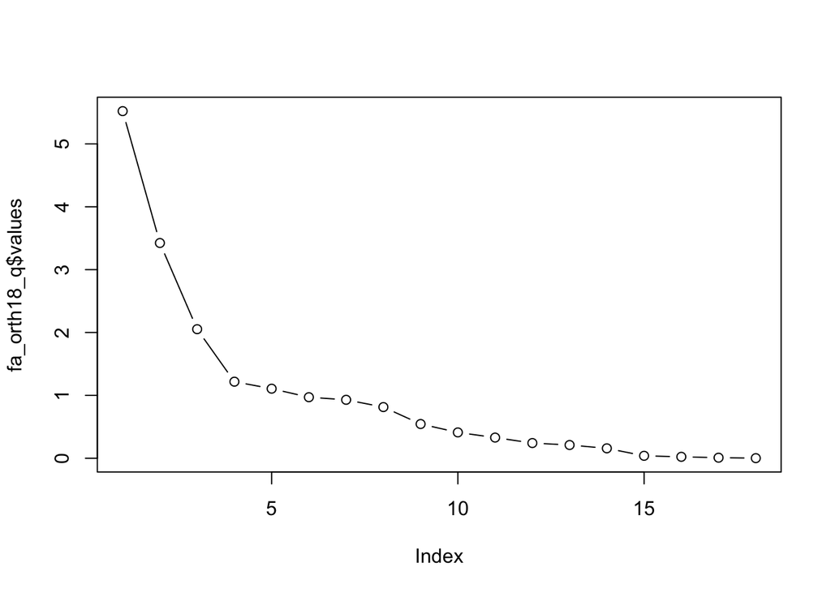

```r
plot(fa_orth18_q$values, type = "b")
```

```r
#could check from 3 PCs to 6 PCs as the eigenvalues are >1 and it explains more than 60% of the old variables
#The Scree plot, suggested 5 PCs
```

```r
#3 factors
#fa_orth3_q <- principal(loan2_sample, 3, rotate="quartimax")
#print.psych(fa_orth3_q, cut=0.3, sort=TRUE)
```

```r
#4 factors
#fa_orth4_q <- principal(loan2_sample, 4, rotate="quartimax")
#print.psych(fa_orth4_q, cut=0.3, sort=TRUE)
```

```r
#5 factors
fa_orth5_q <- principal(loan2_sample, 5, rotate="quartimax")
print.psych(fa_orth5_q, cut=0.3, sort=TRUE)
```

```
## Principal Components Analysis
## Call: principal(r = loan2_sample, nfactors = 5, rotate = "quartimax")
## Standardized loadings (pattern matrix) based upon correlation matrix
##                     item   RC1   RC2   RC3   RC5   RC4   h2    u2 com
## total_pymnt           13  0.97                         0.95 0.046 1.0
## total_rec_prncp       14  0.94                         0.92 0.079 1.1
## installment            3  0.92                         0.88 0.117 1.1
## loan_amnt              1  0.91                         0.90 0.104 1.2
## last_pymnt_amnt       16  0.52             -0.51       0.60 0.398 2.5
## sub_grade              5        0.97                   0.96 0.038 1.0
## int_rate               2        0.97                   0.95 0.047 1.0
## grade                  4        0.96                   0.94 0.064 1.0
## total_rec_int         15  0.59  0.59                   0.76 0.235 2.4
## verification_status    8 -0.32 -0.38                   0.37 0.629 3.5
## total_acc             12              0.86             0.78 0.221 1.1
## open_acc              10              0.85             0.76 0.236 1.1
## revol_bal             11  0.32              0.74       0.71 0.293 1.6
## total_credit_rv       18  0.32        0.31  0.64       0.69 0.308 2.5
## dti                    9              0.31       -0.74 0.73 0.269 1.7
## annual_inc             7  0.41              0.37  0.59 0.72 0.284 3.0
## tot_cur_bal           17              0.32  0.40  0.46 0.53 0.465 3.4
## emp_length             6                               0.16 0.845 2.9
##
##                        RC1  RC2  RC3  RC5  RC4
## SS loadings           4.71 3.56 1.95 1.77 1.33
## Proportion Var        0.26 0.20 0.11 0.10 0.07
## Cumulative Var        0.26 0.46 0.57 0.67 0.74
## Proportion Explained  0.35 0.27 0.15 0.13 0.10
## Cumulative Proportion 0.35 0.62 0.77 0.90 1.00
##
## Mean item complexity =  1.8
## Test of the hypothesis that 5 components are sufficient.
##
## The root mean square of the residuals (RMSR) is  0.06
##  with the empirical chi square  576.42  with prob <  2.6e-79
##
## Fit based upon off diagonal values = 0.97
```

```r
#fa.diagram(fa_orth5_q)
```

```r
#6 factors
#fa_orth6_q <- principal(loan2_sample, 6, rotate="quartimax")
#print.psych(fa_orth6_q, cut=0.3, sort=TRUE)
```

2.Varimax

```r
#18 factors
#fa_orth18_v <- principal(loan2_sample, 18, rotate="varimax")
#print.psych(fa_orth18_v, cut=0.3, sort=TRUE)
#plot(fa_orth18_v$values, type = "b")
#could check from 4 PCs to 6 PCs as the eigenvalues are >1 and it explains more than 60% of the old variables
#The Scree plot, suggested 5 PCs
```

```r
#4 factors
#fa_orth4_v <- principal(loan2_sample, 4, rotate="varimax")
#print.psych(fa_orth4_v, cut=0.3, sort=TRUE)
```

```r
#5 factors
#fa_orth5_v <- principal(loan2_sample, 5, rotate="varimax")
#print.psych(fa_orth5_v, cut=0.3, sort=TRUE)
```

```r
#6 factors
#fa_orth6_v <- principal(loan2_sample, 6, rotate="varimax")
#print.psych(fa_orth6_v, cut=0.3, sort=TRUE)
```

3.Equamax

```r
#18 factors
#fa_orth18_e <- principal(loan2_sample, 18, rotate="equamax")
#print.psych(fa_orth18_e, cut=0.3, sort=TRUE)
#plot(fa_orth18_e$values, type = "b")
#Takes upto 10 PCs to explain 60% of the old variables, hence will not help in explaining clusters as god as previous rotaitons
#The Scree plot, suggested 5 PCs
```

### Maximum Likelihood (ML) Extraction

We tried to use ML extraction with all the rotations too, however, the results from using PC extractions are better for all methods. Thus, we will not be using this extraction for our cluster analysis.

#### No rotation

```r
#18 factors
#fa <- (fa(loan2_sample,18,n.obs=500, rotate="none", fm="ml"))
#print(fa,cut=0.3,sort='true')
#could check 3 factors as the eigenvalues are >1 and it explains almost 60% of the old variables
```

```r
#3 factors
#fa_3 <- (fa(loan2_sample, 3, n.obs=500, rotate="none", fm="ml"))
#print(fa_3,cut=0.3,sort='true')
```

#### Oblimin Rotation

```r
# 18 Factors
#fa18o <- (fa(loan2_sample,18, n.obs=500, rotate="oblimin", fm="ml"))
#print.psych(fa18o, cut=0.3,sort="TRUE")
#fa.diagram(fa18o)
#could check 6 factors as the eigenvalues are >1 and it explains almost 60% of the old variables
```

```r
# 6 Factors
#fa6o <- (fa(loan2_sample,6, n.obs=500, rotate="oblimin", fm="ml"))
#print.psych(fa6o, cut=0.3,sort="TRUE")
```

#### Orthogonal rotation

```r
# 18 Factors
#fa18v <- (fa(loan2_sample,18, n.obs=500, rotate="varimax", fm="ml"))
#print.psych(fa18v, cut=0.3,sort="TRUE")
#fa.diagram(fa18v)
#could check from 4 to 5 factors as the eigenvalues are >1 and it explains almost 60% of the old variables
```

```r
# 4 Factors
#fa4v <- (fa(loan2_sample,4, n.obs=500, rotate="varimax", fm="ml"))
#print.psych(fa4v, cut=0.3,sort="TRUE")
```

```r
# 5 Factors
#fa5v <- (fa(loan2_sample,5, n.obs=500, rotate="varimax", fm="ml"))
#print.psych(fa5v, cut=0.3,sort="TRUE")
```

#### Best Rotation factor scores for loan2_sample

```r
#Though there are few cross loadings, this is the best out of all rotations
fa_orth5_q <- principal(loan2_sample, 5, rotate="quartimax", scores=TRUE)
head(fa_orth5_q$scores, 10)
```

```
##              RC1        RC2         RC3         RC5        RC4
##  [1,] -1.4406978  0.6510975  0.66482708 -0.03309774  0.2438772
##  [2,] -1.3553172 -0.4848792  1.34936644 -0.02412861 -1.4854838
##  [3,] -1.0091194 -0.3977805  1.74639903 -0.08966251 -0.5484284
##  [4,]  1.3205985 -0.7232432 -0.59264783 -1.16362319 -1.1597049
##  [5,]  0.8003874 -0.3755315 -0.34161302  0.49392105  0.3376482
##  [6,] -0.3692927  1.7541051 -1.32955312 -0.85827541 -0.2227662
##  [7,] -0.8866723 -0.7446248 -0.33735887  0.01906420 -0.2327404
##  [8,] -0.7954658  0.9089009 -0.01852158 -0.84583878  0.5428354
##  [9,]  0.1605745 -0.4302710  0.08888270 -1.34003647  0.2468695
## [10,]  0.8703404 -1.7245378 -1.46457489  4.95016836 -0.3498266
```

```r
loan2_fscores <- fa_orth5_q$scores
#fscores are already in a standardised form, hence do not need to normalise
```

Describe loan2_fscore

```r
describe(loan2_fscores)
```

```
##     vars   n mean sd median trimmed  mad   min  max range skew kurtosis   se
## RC1    1 500    0  1  -0.19   -0.08 0.97 -1.89 3.27  5.16 0.72     0.17 0.04
## RC2    2 500    0  1  -0.08   -0.04 0.99 -1.86 3.05  4.91 0.37    -0.37 0.04
## RC3    3 500    0  1  -0.08   -0.05 0.97 -2.30 3.71  6.01 0.49     0.03 0.04
## RC5    4 500    0  1  -0.16   -0.07 0.76 -2.53 4.95  7.48 1.20     3.62 0.04
## RC4    5 500    0  1  -0.05   -0.02 0.94 -2.42 3.44  5.86 0.28     0.20 0.04
```

Check assumptions to see whether our fscores are suitable for cluster analysis

```r
FscoresMatrix <- lowerCor(loan2_fscores)
```

```
##     RC1 RC2 RC3 RC5 RC4
## RC1 1
## RC2 0   1
## RC3 0   0   1
## RC5 0   0   0   1
## RC4 0   0   0   0   1
```

```r
print(FscoresMatrix)
```

```
##               RC1           RC2           RC3           RC5           RC4
## RC1  1.000000e+00  5.984970e-16 -1.539628e-16  5.685721e-16  1.109111e-16
## RC2  5.984970e-16  1.000000e+00 -6.421049e-16 -1.932322e-16 -9.405747e-16
## RC3 -1.539628e-16 -6.421049e-16  1.000000e+00  1.649760e-15  1.081967e-15
## RC5  5.685721e-16 -1.932322e-16  1.649760e-15  1.000000e+00 -1.240658e-16
## RC4  1.109111e-16 -9.405747e-16  1.081967e-15 -1.240658e-16  1.000000e+00
```

```r
#no correlation
```

Create loan3

```r
loan3 <- loan_no_id
loan3_id <- loan2
```

Calculate Mahalanobis distance to identify potential outliers.

```r
#Calculate
Maha_3 <- mahalanobis(loan3, colMeans(loan3), cov(loan3))

#Checking P-values of Maha Distance (to identify distances that are statistically sigificant)
MahaPvalue_3 <- pchisq(Maha_3, df=30, lower.tail = FALSE)

#Check number of outliers we have
print(sum(MahaPvalue_3 < 0.001))
```

```
## [1] 688
```

A p-value that is less than 0.001 is considered to be an outlier. In this case, there are 688 observations with p values less than 0.001. We can consider dropping them for the cluster analysis.

Identify which one to drop with data and drop outliers

```r
#See which observartion is an outlier
IntelMaha_3 <- cbind(loan3, Maha_3, MahaPvalue_3)
loan3 <- filter(IntelMaha_3, MahaPvalue_3 > 0.001)

#Drop Outliers
loan3 <- loan3 %>% select(-c('Maha_3', 'MahaPvalue_3'))
```

```r
set.seed(456)
loan3_sample_id <- sample_n(loan3_id, 500)
loan3_sample <- loan3_sample_id %>% select(!id)

summary(loan3_sample)
```

```
##    loan_amnt        int_rate      installment          grade
##  Min.   : 1200   Min.   : 6.03   Min.   :  42.95   Min.   :1.00
##  1st Qu.: 8831   1st Qu.:11.14   1st Qu.: 288.93   1st Qu.:2.00
##  Median :13000   Median :14.33   Median : 423.65   Median :3.00
##  Mean   :14811   Mean   :14.36   Mean   : 461.99   Mean   :2.73
##  3rd Qu.:20000   3rd Qu.:17.77   3rd Qu.: 593.17   3rd Qu.:4.00
##  Max.   :35000   Max.   :23.83   Max.   :1309.49   Max.   :6.00
##    sub_grade       emp_length       annual_inc     verification_status
##  Min.   : 1.00   Min.   : 1.000   Min.   : 14144   Min.   :1.00
##  1st Qu.: 7.00   1st Qu.: 3.000   1st Qu.: 47450   1st Qu.:1.00
##  Median :11.00   Median : 6.000   Median : 65000   Median :1.00
##  Mean   :11.68   Mean   : 6.078   Mean   : 72272   Mean   :1.78
##  3rd Qu.:16.00   3rd Qu.:10.000   3rd Qu.: 87125   3rd Qu.:3.00
##  Max.   :30.00   Max.   :10.000   Max.   :282000   Max.   :3.00
##       dti           open_acc       revol_bal        total_acc
##  Min.   : 0.26   Min.   : 3.00   Min.   :    16   Min.   : 6.00
##  1st Qu.:11.74   1st Qu.: 8.75   1st Qu.:  7708   1st Qu.:17.75
##  Median :17.61   Median :11.00   Median : 12894   Median :23.00
##  Mean   :17.86   Mean   :11.35   Mean   : 16482   Mean   :25.17
##  3rd Qu.:23.75   3rd Qu.:14.00   3rd Qu.: 21179   3rd Qu.:32.00
##  Max.   :34.83   Max.   :33.00   Max.   :112458   Max.   :58.00
##   total_pymnt      total_rec_prncp   total_rec_int      last_pymnt_amnt
##  Min.   :  648.3   Min.   :  387.6   Min.   :   60.44   Min.   :    2.42
##  1st Qu.: 8931.1   1st Qu.: 7000.0   1st Qu.: 1197.75   1st Qu.:  430.74
##  Median :13746.1   Median :10750.0   Median : 2386.23   Median :  908.00
##  Mean   :15746.0   Mean   :12251.3   Mean   : 3354.39   Mean   : 3984.99
##  3rd Qu.:21600.8   3rd Qu.:16056.0   3rd Qu.: 4386.86   3rd Qu.: 5878.94
##  Max.   :46060.6   Max.   :35000.0   Max.   :17563.23   Max.   :32939.33
##   tot_cur_bal     total_credit_rv
##  Min.   :    18   Min.   :  2200
##  1st Qu.: 31922   1st Qu.: 14775
##  Median : 98102   Median : 23750
##  Mean   :149737   Mean   : 28867
##  3rd Qu.:222265   3rd Qu.: 37450
##  Max.   :952528   Max.   :139800
```

#### Oblique rotation for data without outliers

1.Promax

```r
#18 factors
#fa3_obli18_p <- principal(loan3_sample, 18, rotate="promax")
#print.psych(fa3_obli18_p, cut=0.3, sort=TRUE)
#plot(fa3_obli18_p$values, type = "b")
#could check from 5 PCs to 7 PCs as the eigenvalues are >1 and it explains more than 60% of the old variables
#The Scree plot, suggested 5 or 10 PCs
```

```r
#5 factors
#fa3_obli5_p <- principal(loan3_sample, 5, rotate="promax")
#print.psych(fa3_obli5_p, cut=0.3, sort=TRUE)
```

```r
#6 factors
#fa3_obli6_p <- principal(loan3_sample, 6, rotate="promax")
#print.psych(fa3_obli6_p, cut=0.3, sort=TRUE)
```

```r
#7 factors
#fa3_obli7_p <- principal(loan3_sample, 7, rotate="promax")
#print.psych(fa3_obli7_p, cut=0.3, sort=TRUE)
```

2.Oblimin

```r
#18 factors
#fa3_obli18_o <- principal(loan3_sample, 18, rotate="oblimin")
#print.psych(fa3_obli18_o, cut=0.3, sort=TRUE)
#plot(fa3_obli18_o$values, type = "b")
#could check from 6 PCs to 9 PCs as the eigenvalues are >1 and it explains about 60% of the old variables
#The Scree plot, suggested 5 or 10 PCs
```

```r
#6 factors
#fa3_obli6_o <- principal(loan3_sample, 6, rotate="oblimin")
#print.psych(fa3_obli6_o, cut=0.3, sort=TRUE)
```

```r
#7 factors
#fa3_obli7_o <- principal(loan3_sample, 7, rotate="oblimin")
#print.psych(fa3_obli7_o, cut=0.3, sort=TRUE)
```

```r
#8 factors
#fa3_obli8_o <- principal(loan3_sample, 8, rotate="oblimin")
#print.psych(fa3_obli8_o, cut=0.3, sort=TRUE)
```

```r
#9 factors
#fa3_obli9_o <- principal(loan3_sample, 9, rotate="oblimin")
#print.psych(fa3_obli9_o, cut=0.3, sort=TRUE)
#Gives least cross loadings but produces high correlations
```

#### Orthogonal rotation for data without outliers

1.Quartimax

```r
#18 factors
#fa3_orth18_q <- principal(loan3_sample, 18, rotate="quartimax")
#print.psych(fa3_orth18_q, cut=0.3, sort=TRUE)
#plot(fa3_orth18_q$values, type = "b")
#could check from 4 PCs to 6 PCs as the eigenvalues are >1 and it explains more than 60% of the old variables
#The Scree plot, suggested 5 PCs
```

```r
#4 factors
#fa3_orth4_q <- principal(loan3_sample, 4, rotate="quartimax")
#print.psych(fa3_orth4_q, cut=0.3, sort=TRUE)
```

```r
#5 factors
#fa3_orth5_q <- principal(loan3_sample, 5, rotate="quartimax")
#print.psych(fa3_orth5_q, cut=0.3, sort=TRUE)
```

```r
#6 factors
#fa3_orth6_q <- principal(loan3_sample, 6, rotate="quartimax")
#print.psych(fa3_orth6_q, cut=0.3, sort=TRUE)
```

2.Varimax

```r
#18 factors
fa3_orth18_v <- principal(loan3_sample, 18, rotate="varimax")
print.psych(fa3_orth18_v, cut=0.3, sort=TRUE)
```

```
## Principal Components Analysis
## Call: principal(r = loan3_sample, nfactors = 18, rotate = "varimax")
## Standardized loadings (pattern matrix) based upon correlation matrix
##                     item   RC1   RC2   RC7   RC5   RC3   RC4   RC9   RC6  RC11
## installment            3  0.94
## total_pymnt           13  0.93
## loan_amnt              1  0.91
## total_rec_prncp       14  0.88              0.30
## total_rec_int         15  0.61  0.50
## sub_grade              5        0.98
## int_rate               2        0.98
## grade                  4        0.98
## revol_bal             11              0.92
## total_credit_rv       18              0.83
## last_pymnt_amnt       16                    0.95
## open_acc              10                          0.92
## dti                    9                                0.96
## tot_cur_bal           17                                      0.94
## emp_length             6                                            0.99
## total_acc             12                          0.34                    0.90
## verification_status    8
## annual_inc             7
##                       RC8  RC10  RC12  RC14  RC13  RC15  RC16  RC17  RC18 h2
## installment                                                                1
## total_pymnt                                                                1
## loan_amnt                                                                  1
## total_rec_prncp                                                            1
## total_rec_int                    0.57                                      1
## sub_grade                                                                  1
## int_rate                                                                   1
## grade                                                                      1
## revol_bal                                                                  1
## total_credit_rv                        0.40                                1
## last_pymnt_amnt                                                            1
## open_acc                                                                   1
## dti                                                                        1
## tot_cur_bal                                                                1
## emp_length                                                                 1
## total_acc                                                                  1
## verification_status -0.94                                                  1
```

[output cut: 26 more lines]

```
## Cumulative Proportion 0.23 0.41 0.51 0.57 0.62 0.68 0.74 0.79 0.85 0.90 0.95
##                       RC12 RC14 RC13 RC15 RC16 RC17 RC18
## SS loadings           0.37 0.22 0.22 0.04 0.03 0.01    0
## Proportion Var        0.02 0.01 0.01 0.00 0.00 0.00    0
## Cumulative Var        0.97 0.98 1.00 1.00 1.00 1.00    1
## Proportion Explained  0.02 0.01 0.01 0.00 0.00 0.00    0
## Cumulative Proportion 0.97 0.98 1.00 1.00 1.00 1.00    1
##
## Mean item complexity =  1.4
## Test of the hypothesis that 18 components are sufficient.
##
## The root mean square of the residuals (RMSR) is  0
##  with the empirical chi square  0  with prob <  NA
##
## Fit based upon off diagonal values = 1
```

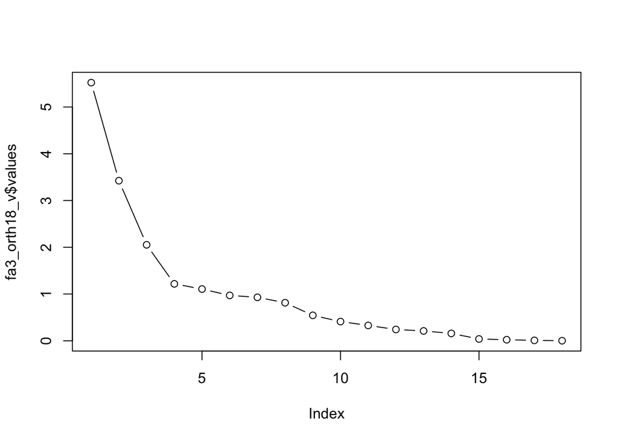

```r
plot(fa3_orth18_v$values, type = "b")
```

```r
#could check from 4 PCs to 6 PCs as the eigenvalues are >1 and it explains more than 60% of the old variables
#The Scree plot, suggested 5 PCs
```

```r
#4 factors
fa3_orth4_v <- principal(loan3_sample, 4, rotate="varimax")
print.psych(fa3_orth4_v, cut=0.3, sort=TRUE)
```

```
## Principal Components Analysis
## Call: principal(r = loan3_sample, nfactors = 4, rotate = "varimax")
## Standardized loadings (pattern matrix) based upon correlation matrix
##                     item   RC1   RC2   RC4   RC3   h2    u2 com
## total_rec_prncp       14  0.93                   0.92 0.084 1.1
## total_pymnt           13  0.92                   0.95 0.046 1.2
## installment            3  0.85        0.32       0.87 0.127 1.4
## loan_amnt              1  0.83        0.34       0.88 0.121 1.6
## last_pymnt_amnt       16  0.60                   0.38 0.618 1.1
## sub_grade              5        0.97             0.95 0.047 1.0
## int_rate               2        0.97             0.95 0.054 1.0
## grade                  4        0.96             0.92 0.077 1.0
## total_rec_int         15  0.48  0.65             0.73 0.274 2.2
## verification_status    8       -0.42             0.31 0.689 2.5
## annual_inc             7              0.78       0.67 0.326 1.2
## tot_cur_bal           17              0.70       0.50 0.496 1.1
## revol_bal             11              0.65  0.35 0.56 0.442 1.7
## total_credit_rv       18              0.62  0.37 0.62 0.379 2.2
## emp_length             6              0.36       0.15 0.855 1.2
## open_acc              10                    0.80 0.67 0.330 1.1
## dti                    9                    0.71 0.59 0.415 1.3
## total_acc             12              0.37  0.67 0.59 0.405 1.6
##
##                        RC1  RC2  RC4  RC3
## SS loadings           3.92 3.68 2.68 1.93
## Proportion Var        0.22 0.20 0.15 0.11
## Cumulative Var        0.22 0.42 0.57 0.68
## Proportion Explained  0.32 0.30 0.22 0.16
## Cumulative Proportion 0.32 0.62 0.84 1.00
##
## Mean item complexity =  1.4
## Test of the hypothesis that 4 components are sufficient.
##
## The root mean square of the residuals (RMSR) is  0.07
##  with the empirical chi square  772.22  with prob <  2.2e-110
##
## Fit based upon off diagonal values = 0.95
```

```r
#Least cross loading
```

```r
#5 factors
#fa3_orth5_v <- principal(loan3_sample, 5, rotate="varimax")
#print.psych(fa3_orth5_v, cut=0.3, sort=TRUE)
```

```r
#6 factors
#fa3_orth6_v <- principal(loan3_sample, 6, rotate="varimax")
#print.psych(fa3_orth6_v, cut=0.3, sort=TRUE)
```

3.Equamax

```r
#18 factors
#fa3_orth18_e <- principal(loan3_sample, 18, rotate="equamax")
#print.psych(fa3_orth18_e, cut=0.3, sort=TRUE)
#plot(fa3_orth18_e$values, type = "b")
#Takes upto 10 PCs to explain 60% of the old variables, hence will not help in explaining clusters as god as previous rotaitons
#The Scree plot, suggested 5 PCs
```

#### Best Rotation factor scores for loan3_sample

```r
#Though there are few cross loadings, this is the best out of all rotations
fa3_orth4_v <- principal(loan3_sample, 4, rotate="varimax", scores=TRUE)
print.psych(fa3_orth4_v, cut=0.3, sort=TRUE)
```

```
## Principal Components Analysis
## Call: principal(r = loan3_sample, nfactors = 4, rotate = "varimax",
##     scores = TRUE)
## Standardized loadings (pattern matrix) based upon correlation matrix
##                     item   RC1   RC2   RC4   RC3   h2    u2 com
## total_rec_prncp       14  0.93                   0.92 0.084 1.1
## total_pymnt           13  0.92                   0.95 0.046 1.2
## installment            3  0.85        0.32       0.87 0.127 1.4
## loan_amnt              1  0.83        0.34       0.88 0.121 1.6
## last_pymnt_amnt       16  0.60                   0.38 0.618 1.1
## sub_grade              5        0.97             0.95 0.047 1.0
## int_rate               2        0.97             0.95 0.054 1.0
## grade                  4        0.96             0.92 0.077 1.0
## total_rec_int         15  0.48  0.65             0.73 0.274 2.2
## verification_status    8       -0.42             0.31 0.689 2.5
## annual_inc             7              0.78       0.67 0.326 1.2
## tot_cur_bal           17              0.70       0.50 0.496 1.1
## revol_bal             11              0.65  0.35 0.56 0.442 1.7
## total_credit_rv       18              0.62  0.37 0.62 0.379 2.2
## emp_length             6              0.36       0.15 0.855 1.2
## open_acc              10                    0.80 0.67 0.330 1.1
## dti                    9                    0.71 0.59 0.415 1.3
## total_acc             12              0.37  0.67 0.59 0.405 1.6
##
##                        RC1  RC2  RC4  RC3
## SS loadings           3.92 3.68 2.68 1.93
## Proportion Var        0.22 0.20 0.15 0.11
## Cumulative Var        0.22 0.42 0.57 0.68
## Proportion Explained  0.32 0.30 0.22 0.16
## Cumulative Proportion 0.32 0.62 0.84 1.00
##
## Mean item complexity =  1.4
## Test of the hypothesis that 4 components are sufficient.
##
## The root mean square of the residuals (RMSR) is  0.07
##  with the empirical chi square  772.22  with prob <  2.2e-110
##
## Fit based upon off diagonal values = 0.95
```

```r
loan3_fscores <- fa3_orth4_v$scores
#fscores are already in a standardised form, hence do not need to normalise
```

Check assumptions to see whether our fscores are suitable for cluster analysis

```r
FscoresMatrix3 <- lowerCor(loan3_fscores)
```

```
##     RC1 RC2 RC4 RC3
## RC1 1
## RC2 0   1
## RC4 0   0   1
## RC3 0   0   0   1
```

```r
print(FscoresMatrix3)
```

```
##               RC1           RC2           RC4           RC3
## RC1  1.000000e+00  9.749494e-16  1.757668e-16 -1.290440e-16
## RC2  9.749494e-16  1.000000e+00 -1.425713e-15 -3.533135e-16
## RC4  1.757668e-16 -1.425713e-15  1.000000e+00  2.291643e-16
## RC3 -1.290440e-16 -3.533135e-16  2.291643e-16  1.000000e+00
```

```r
#no high correlation
```

#Hierarchical Cluster Analysis

Define linkage methods, try all methods

```r
m <- c("average", "single", "complete", "ward")
names(m) <- c("average", "single", "complete", "ward")
```

Compute agglomerative coefficient (Find metric that measures strength of the clusters, closer to 1 means stronger clusters) and compare agglomerative coefficient for each methods

```r
#Loan2
ac <- function(x) {
  agnes(loan2_fscores, method = x)$ac
}

sapply(m, ac)
```

```
##   average    single  complete      ward
## 0.8558682 0.6900255 0.9053417 0.9635276
```

```r
#Loan3
ac <- function(x) {
  agnes(loan3_fscores, method = x)$ac
}

sapply(m, ac)
```

```
##   average    single  complete      ward
## 0.8727184 0.6991805 0.9222874 0.9741343
```

Ward’s minimum variance method have the highest agglomerative coefficient, hence we will use this method

Calculate gap statistic for each number of clusters in loan2_fscores (up to 10 clusters)

```r
gap_stat_2 <- clusGap(loan2_fscores, FUN = hcut, nstart = 25, K.max = 10, B = 50)
```

Plot clusters vs. Gap statistic

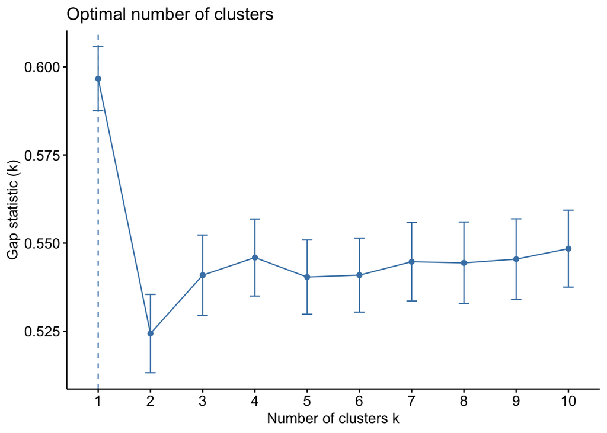

```r
fviz_gap_stat(gap_stat_2)
```

Calculate gap statistic for each number of clusters in loan3_fscores (up to 10 clusters)

```r
gap_stat_3 <- clusGap(loan3_fscores, FUN = hcut, nstart = 25, K.max = 10, B = 50)
```

Plot clusters vs. Gap statistic

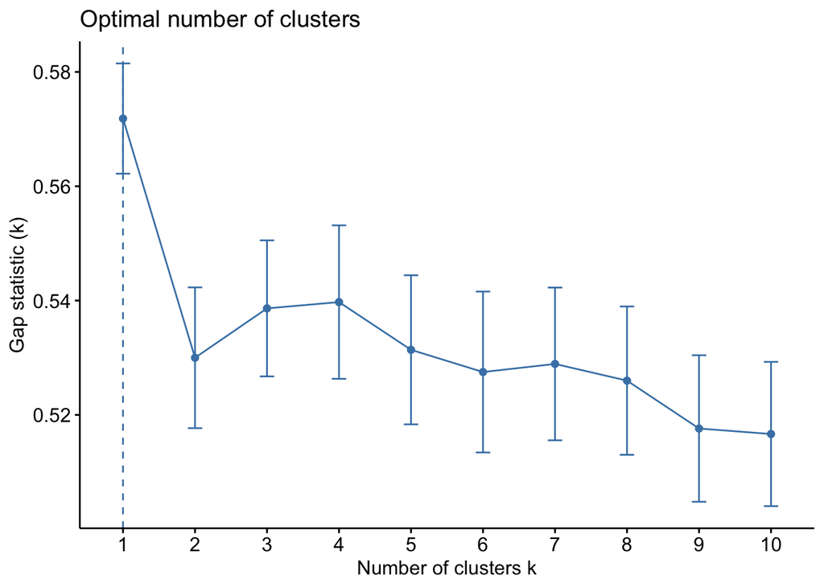

```r
fviz_gap_stat(gap_stat_3)
```

Finding distance matrix, using euclidean distance calculation method

```r
distance_mat_2 <- dist(loan2_fscores, method = 'euclidean')
distance_mat_3 <- dist(loan3_fscores, method = 'euclidean')
```

Fitting Hierarchical clustering Model to dataset

```r
set.seed(500)
Hierar_cl_2 <- hclust(distance_mat_2, method = "ward")
```

```
## The "ward" method has been renamed to "ward.D"; note new "ward.D2"
```

```r
Hierar_cl_2
```

```
##
## Call:
## hclust(d = distance_mat_2, method = "ward")
##
## Cluster method   : ward.D
## Distance         : euclidean
## Number of objects: 500
```

```r
set.seed(500)
Hierar_cl_3 <- hclust(distance_mat_3, method = "ward")
```

```
## The "ward" method has been renamed to "ward.D"; note new "ward.D2"
```

```r
Hierar_cl_3
```

```
##
## Call:
## hclust(d = distance_mat_3, method = "ward")
##
## Cluster method   : ward.D
## Distance         : euclidean
## Number of objects: 500
```

Dendrogram Plot

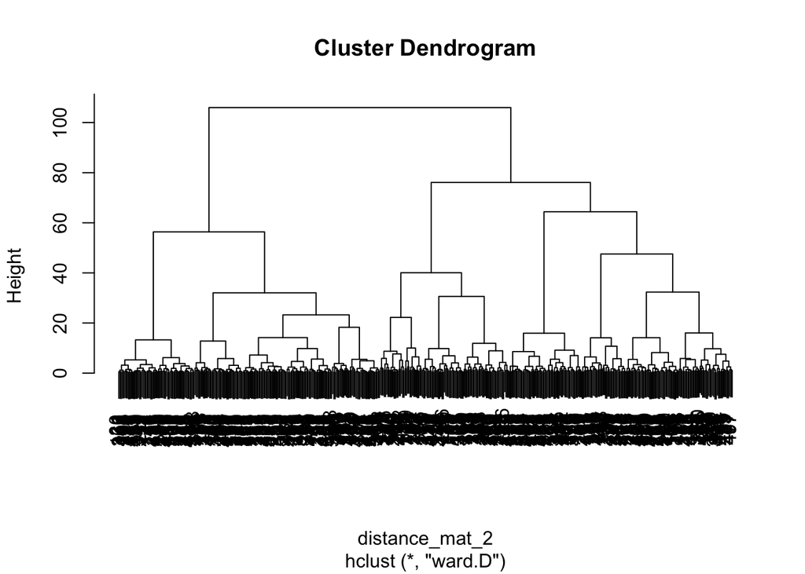

```r
plot(Hierar_cl_2)
```

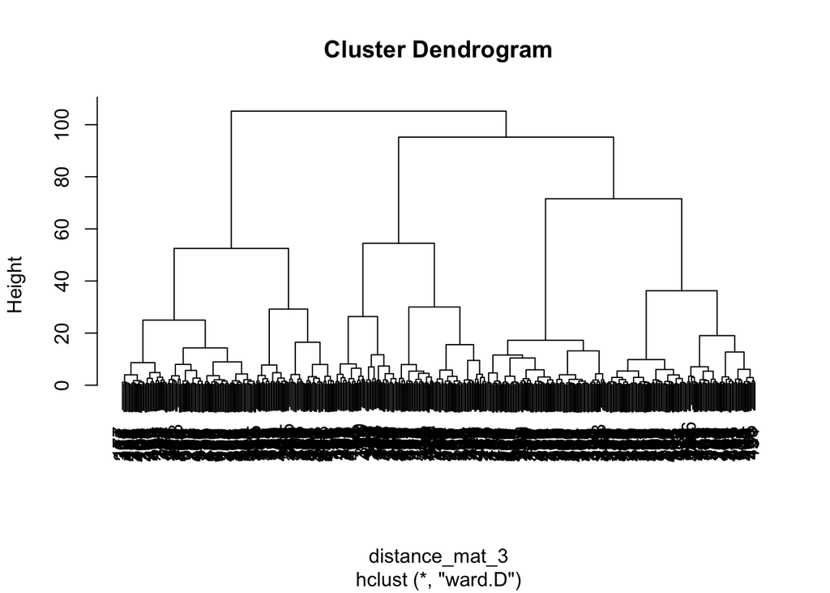

```r
plot(Hierar_cl_3)
```

Observe size of clusters

```r
#Apply number of clusters we chose and observe each cluster (number of observations)
fit_2 <- cutree(Hierar_cl_2, k = 4)
table(fit_2)
```

```
## fit_2
##   1   2   3   4
## 105 123  59 213
```

```r
fit_3 <- cutree(Hierar_cl_3, k = 4)
table(fit_3)
```

```
## fit_3
##   1   2   3   4
## 168 118  94 120
```

Though model without outliers has a more reasonable sized clusters, both models gives appropriate clusters. Therefore, we choose the model that is more stable throughout all data samples. This is done with validation as we want to validate of choosing model without outliers will be more stable.

## Gap Validation

Creating sample of 500 observations with different random seeds

```r
set.seed(400)
loan2_sample_vali_id <- sample_n(loan2, 500)
loan2_sample_vali <- loan2_sample_vali_id%>%select(!id)
summary(loan2_sample_vali)
```

```
##    loan_amnt        int_rate      installment          grade
##  Min.   : 1000   Min.   : 6.03   Min.   :  32.81   Min.   :1.000
##  1st Qu.: 8000   1st Qu.:11.14   1st Qu.: 261.52   1st Qu.:2.000
##  Median :13212   Median :14.09   Median : 423.61   Median :2.000
##  Mean   :14750   Mean   :14.31   Mean   : 457.75   Mean   :2.744
##  3rd Qu.:20000   3rd Qu.:17.77   3rd Qu.: 601.85   3rd Qu.:4.000
##  Max.   :35000   Max.   :24.83   Max.   :1278.55   Max.   :7.000
##    sub_grade       emp_length       annual_inc     verification_status
##  Min.   : 1.00   Min.   : 1.000   Min.   : 18000   Min.   :1.00
##  1st Qu.: 7.00   1st Qu.: 3.000   1st Qu.: 47684   1st Qu.:1.00
##  Median :10.00   Median : 6.000   Median : 65000   Median :2.00
##  Mean   :11.59   Mean   : 6.038   Mean   : 75432   Mean   :1.91
##  3rd Qu.:16.00   3rd Qu.:10.000   3rd Qu.: 90000   3rd Qu.:3.00
##  Max.   :32.00   Max.   :10.000   Max.   :729368   Max.   :3.00
##       dti           open_acc       revol_bal        total_acc
##  Min.   : 0.30   Min.   : 2.00   Min.   :     0   Min.   : 3.00
##  1st Qu.:11.29   1st Qu.: 8.00   1st Qu.:  7392   1st Qu.:17.00
##  Median :17.01   Median :10.00   Median : 14293   Median :23.00
##  Mean   :16.81   Mean   :11.02   Mean   : 17980   Mean   :24.78
##  3rd Qu.:22.41   3rd Qu.:14.00   3rd Qu.: 23565   3rd Qu.:31.25
##  Max.   :34.55   Max.   :26.00   Max.   :193945   Max.   :59.00
##   total_pymnt    total_rec_prncp   total_rec_int      last_pymnt_amnt
##  Min.   :  328   Min.   :  222.7   Min.   :   40.76   Min.   :    1.84
##  1st Qu.: 7634   1st Qu.: 6000.0   1st Qu.: 1139.32   1st Qu.:  372.67
##  Median :13297   Median :10358.4   Median : 2165.94   Median :  843.68
##  Mean   :15546   Mean   :12256.9   Mean   : 3181.44   Mean   : 4145.23
##  3rd Qu.:21602   3rd Qu.:16979.5   3rd Qu.: 3832.05   3rd Qu.: 5539.56
##  Max.   :48248   Max.   :35000.0   Max.   :16529.05   Max.   :33495.91
##   tot_cur_bal      total_credit_rv
##  Min.   :     18   Min.   :   800
##  1st Qu.:  27256   1st Qu.: 13175
##  Median :  88554   Median : 23850
##  Mean   : 146221   Mean   : 30357
##  3rd Qu.: 225049   3rd Qu.: 39700
##  Max.   :1260194   Max.   :222400
```

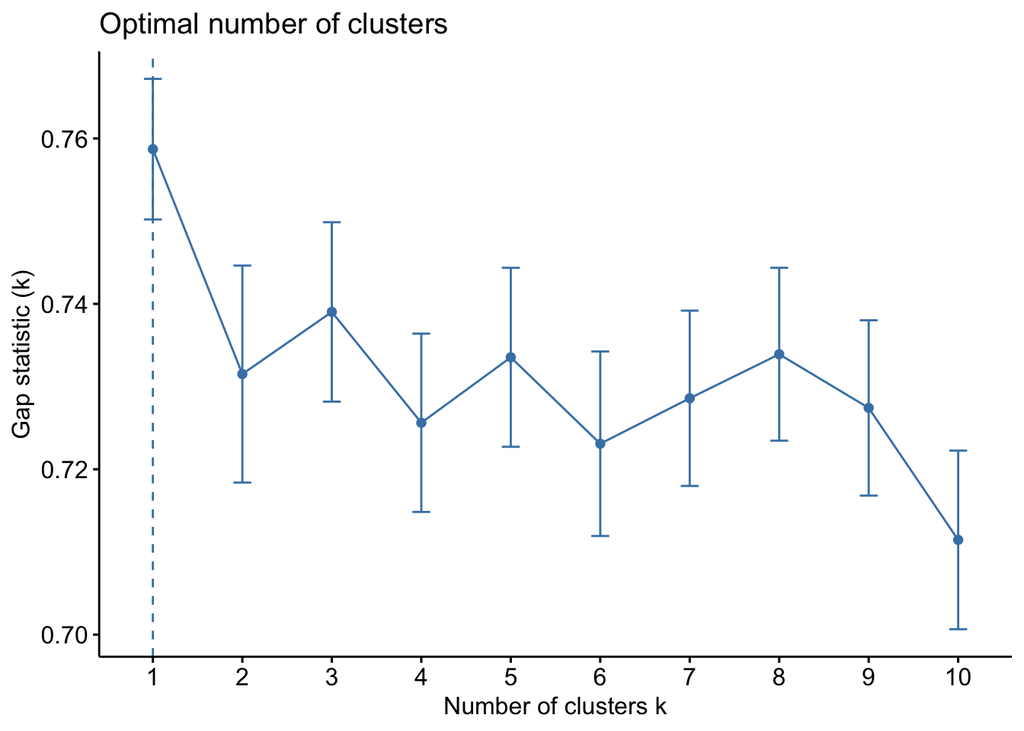

```r
#fscores for validation
fa_orth5_q_vali <- principal(loan2_sample_vali, 5, rotate="quartimax", scores=TRUE)
loan2_fscores_vali <- fa_orth5_q_vali$scores

#Calculate gap statistic for each number of clusters in loan3_fscores (up to 10 clusters)
gap_stat_2_vali <- clusGap(loan2_fscores_vali, FUN = hcut, nstart = 25, K.max = 10, B = 50)

#Plot clusters vs. Gap statistic
fviz_gap_stat(gap_stat_2_vali)
```

Creating sample of 500 observations with different random seeds

```r
set.seed(426)
loan3_sample_vali_id <- sample_n(loan3_id, 500)
loan3_sample_vali <- loan3_sample_vali_id%>%select(!id)
summary(loan3_sample_vali)
```

```
##    loan_amnt        int_rate      installment          grade
##  Min.   : 1000   Min.   : 6.03   Min.   :  33.75   Min.   :1.000
##  1st Qu.: 8000   1st Qu.:11.14   1st Qu.: 274.71   1st Qu.:2.000
##  Median :12000   Median :14.09   Median : 400.99   Median :2.000
##  Mean   :13979   Mean   :14.23   Mean   : 441.88   Mean   :2.694
##  3rd Qu.:19612   3rd Qu.:17.27   3rd Qu.: 578.37   3rd Qu.:3.000
##  Max.   :35000   Max.   :24.89   Max.   :1336.31   Max.   :7.000
##    sub_grade       emp_length       annual_inc     verification_status
##  Min.   : 1.00   Min.   : 1.000   Min.   : 16000   Min.   :1.00
##  1st Qu.: 7.00   1st Qu.: 3.000   1st Qu.: 45000   1st Qu.:1.00
##  Median :10.00   Median : 6.000   Median : 60550   Median :2.00
##  Mean   :11.44   Mean   : 6.162   Mean   : 71059   Mean   :1.97
##  3rd Qu.:15.00   3rd Qu.:10.000   3rd Qu.: 85000   3rd Qu.:3.00
##  Max.   :33.00   Max.   :10.000   Max.   :390000   Max.   :3.00
##       dti           open_acc       revol_bal        total_acc
##  Min.   : 0.80   Min.   : 2.00   Min.   :     0   Min.   : 4.00
##  1st Qu.:11.47   1st Qu.: 8.00   1st Qu.:  7520   1st Qu.:16.00
##  Median :17.01   Median :10.00   Median : 12666   Median :22.00
##  Mean   :17.55   Mean   :10.99   Mean   : 16619   Mean   :24.01
##  3rd Qu.:23.12   3rd Qu.:14.00   3rd Qu.: 20713   3rd Qu.:31.00
##  Max.   :34.81   Max.   :32.00   Max.   :226081   Max.   :63.00
##   total_pymnt      total_rec_prncp total_rec_int      last_pymnt_amnt
##  Min.   :  739.6   Min.   :  228   Min.   :   45.96   Min.   :    0.2
##  1st Qu.: 7848.6   1st Qu.: 6000   1st Qu.: 1152.78   1st Qu.:  366.8
##  Median :12838.0   Median :10000   Median : 2047.76   Median :  741.0
##  Mean   :14683.8   Mean   :11403   Mean   : 3125.93   Mean   : 3610.8
##  3rd Qu.:19904.5   3rd Qu.:15000   3rd Qu.: 3876.97   3rd Qu.: 4901.3
##  Max.   :46024.3   Max.   :35000   Max.   :17206.91   Max.   :34906.1
##   tot_cur_bal     total_credit_rv
##  Min.   :   300   Min.   :  1300
##  1st Qu.: 25874   1st Qu.: 13850
##  Median : 79970   Median : 22500
##  Mean   :135103   Mean   : 29105
##  3rd Qu.:210010   3rd Qu.: 35822
##  Max.   :727139   Max.   :288300
```

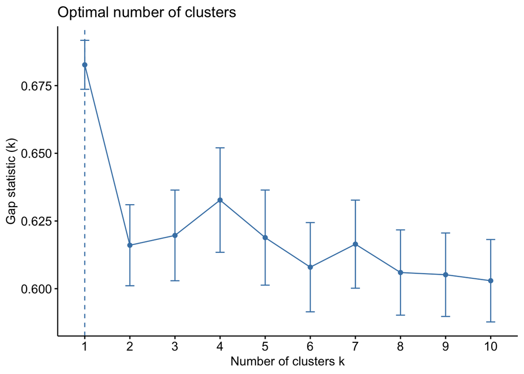

```r
#fscores for validation
fa3_orth4_v_vali <- principal(loan3_sample_vali, 4, rotate="varimax", scores=TRUE)
loan3_fscores_vali <- fa3_orth4_v_vali$scores

#Calculate gap statistic for each number of clusters in loan3_fscores (up to 10 clusters)
gap_stat_3_vali <- clusGap(loan3_fscores_vali, FUN = hcut, nstart = 25, K.max = 10, B = 50)

#Plot clusters vs. Gap statistic
fviz_gap_stat(gap_stat_3_vali)
```

```r
distance_mat_3_vali <- dist(loan3_fscores_vali, method = 'euclidean')

set.seed(500)
Hierar_cl_3_vali <- hclust(distance_mat_3_vali, method = "ward")
```

```
## The "ward" method has been renamed to "ward.D"; note new "ward.D2"
```

```r
Hierar_cl_3_vali
```

```
##
## Call:
## hclust(d = distance_mat_3_vali, method = "ward")
##
## Cluster method   : ward.D
## Distance         : euclidean
## Number of objects: 500
```

```r
fit_3_vali <- cutree(Hierar_cl_3_vali, k = 4)
table(fit_3_vali)
```

```
## fit_3_vali
##   1   2   3   4
## 188  74  74 164
```

## Interpretations

Add lable and see for each observation row, which cluster that observation belongs to

```r
final_data_3 <- cbind(loan3_fscores, cluster = fit_3)
head(final_data_3)
```

```
##             RC1        RC2         RC4         RC3 cluster
## [1,] -1.4734986  0.5080418 -0.09526179  0.39672792       1
## [2,] -1.1397674 -0.6057028 -0.90820383  1.89881458       2
## [3,] -0.9182081 -0.5356385 -0.22091791  1.68835204       2
## [4,]  1.7343892 -0.6253958 -1.33131353 -0.06434783       3
## [5,]  0.6571055 -0.2862729  0.68758784 -0.36841010       4
## [6,] -0.2095480  1.7420887 -1.20670429 -1.09675731       1
```

See characteristics of each clusters by average values of each factors

```r
hcentres_3 <- aggregate(x=final_data_3, by=list(cluster=fit_3), FUN="mean")
print(hcentres_3)
```

```
##   cluster        RC1        RC2        RC4         RC3 cluster
## 1       1 -0.3468579  0.8533403 -0.2283988 -0.37386020       1
## 2       2 -0.1956538 -0.3784707 -0.5386024  0.99703719       2
## 3       3 -0.1094176 -0.8976501 -0.2235754 -0.59894792       3
## 4       4  0.7637044 -0.1193543  1.0245181  0.01216025       4
```

Factors interpretation:

```r
print.psych(fa3_orth4_v, cut=0.3, sort=TRUE)
```

```
## Principal Components Analysis
## Call: principal(r = loan3_sample, nfactors = 4, rotate = "varimax",
##     scores = TRUE)
## Standardized loadings (pattern matrix) based upon correlation matrix
##                     item   RC1   RC2   RC4   RC3   h2    u2 com
## total_rec_prncp       14  0.93                   0.92 0.084 1.1
## total_pymnt           13  0.92                   0.95 0.046 1.2
## installment            3  0.85        0.32       0.87 0.127 1.4
## loan_amnt              1  0.83        0.34       0.88 0.121 1.6
## last_pymnt_amnt       16  0.60                   0.38 0.618 1.1
## sub_grade              5        0.97             0.95 0.047 1.0
## int_rate               2        0.97             0.95 0.054 1.0
## grade                  4        0.96             0.92 0.077 1.0
## total_rec_int         15  0.48  0.65             0.73 0.274 2.2
## verification_status    8       -0.42             0.31 0.689 2.5
## annual_inc             7              0.78       0.67 0.326 1.2
## tot_cur_bal           17              0.70       0.50 0.496 1.1
## revol_bal             11              0.65  0.35 0.56 0.442 1.7
## total_credit_rv       18              0.62  0.37 0.62 0.379 2.2
## emp_length             6              0.36       0.15 0.855 1.2
## open_acc              10                    0.80 0.67 0.330 1.1
## dti                    9                    0.71 0.59 0.415 1.3
## total_acc             12              0.37  0.67 0.59 0.405 1.6
##
##                        RC1  RC2  RC4  RC3
## SS loadings           3.92 3.68 2.68 1.93
## Proportion Var        0.22 0.20 0.15 0.11
## Cumulative Var        0.22 0.42 0.57 0.68
## Proportion Explained  0.32 0.30 0.22 0.16
## Cumulative Proportion 0.32 0.62 0.84 1.00
##
## Mean item complexity =  1.4
## Test of the hypothesis that 4 components are sufficient.
##
## The root mean square of the residuals (RMSR) is  0.07
##  with the empirical chi square  772.22  with prob <  2.2e-110
##
## Fit based upon off diagonal values = 0.95
```

Factor 1: amount of money an individual is involved in transactions i.e. payments and loan Factor 2: risks assigned to that individual in respect to finance Factor 3: bank credits and bank balance Factor 4: stability of income

# Cross Validation

```r
final_data_3_id <- cbind(loan3_sample_id, cluster=fit_3)
final_data_3_id_vali <- cbind(loan3_sample_vali_id, cluster=fit_3_vali)
```

separate into clusters for original cluster sample

```r
cluster1_ori <- final_data_3_id %>% filter(cluster==1)
cluster2_ori <- final_data_3_id %>% filter(cluster==2)
cluster3_ori <- final_data_3_id %>% filter(cluster==3)
cluster4_ori <- final_data_3_id %>% filter(cluster==4)
```

separate into clusters for validated sample

```r
cluster1_vali <- final_data_3_id_vali %>% filter(cluster==1)
cluster2_vali <- final_data_3_id_vali %>% filter(cluster==2)
cluster3_vali <- final_data_3_id_vali %>% filter(cluster==3)
cluster4_vali <- final_data_3_id_vali %>% filter(cluster==4)
```

cross validation to check whether the same observations from both samples are clustered differently

```r
merge_cluster1_valicluster1 <- merge(cluster1_ori, cluster1_vali, by="id")
merge_cluster1_valicluster2 <- merge(cluster1_ori, cluster2_vali, by="id")
merge_cluster1_valicluster3 <- merge(cluster1_ori, cluster3_vali, by="id")
merge_cluster1_valicluster4 <- merge(cluster1_ori, cluster4_vali, by="id")
merge_cluster2_valicluster1 <- merge(cluster2_ori, cluster1_vali, by="id")
merge_cluster2_valicluster2 <- merge(cluster2_ori, cluster2_vali, by="id")
merge_cluster2_valicluster3 <- merge(cluster2_ori, cluster3_vali, by="id")
merge_cluster2_valicluster4 <- merge(cluster2_ori, cluster4_vali, by="id")
merge_cluster3_valicluster1 <- merge(cluster3_ori, cluster1_vali, by="id")
merge_cluster3_valicluster2 <- merge(cluster3_ori, cluster2_vali, by="id")
merge_cluster3_valicluster3 <- merge(cluster3_ori, cluster3_vali, by="id")
merge_cluster3_valicluster4 <- merge(cluster3_ori, cluster4_vali, by="id")
merge_cluster4_valicluster1 <- merge(cluster4_ori, cluster1_vali, by="id")
merge_cluster4_valicluster2 <- merge(cluster4_ori, cluster2_vali, by="id")
merge_cluster4_valicluster3 <- merge(cluster4_ori, cluster3_vali, by="id")
merge_cluster4_valicluster4 <- merge(cluster4_ori, cluster4_vali, by="id")
```

# Non-Hierarchical Cluster Analysis

Kmeans clustering with k=4

```r
set.seed(500)
k_cl <- kmeans(loan3_fscores, 4, nstart=25)
k_cl
```

```
## K-means clustering with 4 clusters of sizes 145, 111, 65, 179
##
## Cluster means:
##          RC1         RC2         RC4        RC3
## 1 -0.2913103 -0.01682896 -0.55589423  0.9558149
## 2  1.2091792  0.72028136  0.07187963 -0.1483509
## 3 -0.1626720 -0.40528912  1.80924330  0.3165055
## 4 -0.4547778 -0.28585049 -0.25125581 -0.7972015
##
## Clustering vector:
##   [1] 1 1 1 2 2 4 4 4 4 3 3 4 2 2 1 4 1 4 1 2 3 4 3 4 3 2 4 4 1 1 4 4 2 1 2 2 4
##  [38] 3 4 4 1 2 2 1 2 4 1 2 1 2 2 3 4 4 2 3 4 4 2 4 3 2 3 3 4 1 1 4 3 3 1 4 4 1
##  [75] 1 3 4 1 4 2 1 4 4 4 1 4 3 4 1 1 3 2 2 1 2 1 4 4 4 1 1 3 2 1 4 1 4 4 2 4 4
## [112] 2 4 1 1 4 1 1 1 4 2 1 2 1 2 3 4 1 2 4 1 4 3 4 1 3 3 1 1 2 4 1 4 4 1 4 4 1
## [149] 1 4 1 4 3 1 4 2 2 3 4 3 4 4 3 4 3 3 1 1 2 4 4 1 2 4 3 4 4 1 4 1 2 3 1 2 4
## [186] 2 4 2 2 1 2 4 3 2 1 4 3 2 1 2 4 3 1 4 4 4 2 4 3 1 1 1 1 3 4 4 2 1 1 1 1 2
## [223] 1 1 4 4 4 4 1 4 2 4 3 1 1 2 4 2 3 2 4 3 1 2 2 2 2 2 1 1 4 4 1 2 4 4 4 4 4
## [260] 2 1 2 4 4 4 4 3 1 3 2 1 1 1 1 2 1 2 4 1 2 1 2 4 3 1 1 4 1 1 2 2 4 1 4 3 2
## [297] 4 1 4 2 1 4 2 4 1 4 4 2 4 4 1 4 1 4 2 2 2 2 1 1 3 4 2 1 1 4 4 2 1 2 4 1 1
## [334] 4 4 1 2 4 4 4 4 4 4 4 4 4 1 1 1 4 2 2 1 1 3 2 1 4 4 4 4 4 4 4 3 1 2 3 2 2
## [371] 1 2 4 1 3 4 1 4 1 1 1 4 4 4 1 1 4 1 2 4 4 3 1 4 1 4 4 2 2 2 1 3 4 2 2 3 4
## [408] 4 4 4 3 2 1 1 1 1 4 1 3 1 4 2 3 3 4 3 2 2 2 3 4 1 3 4 4 4 2 4 3 4 2 2 2 1
## [445] 4 1 4 2 1 1 3 2 2 4 3 3 1 1 1 2 2 4 3 4 4 4 4 4 1 2 3 4 3 1 1 4 1 4 2 4 2
## [482] 2 3 1 2 1 4 1 4 4 2 1 3 1 4 4 1 2 1 4
##
## Within cluster sum of squares by cluster:
## [1] 295.9196 347.4572 220.8021 310.9153
##  (between_SS / total_SS =  41.1 %)
##
## Available components:
##
## [1] "cluster"      "centers"      "totss"        "withinss"     "tot.withinss"
## [6] "betweenss"    "size"         "iter"         "ifault"
```